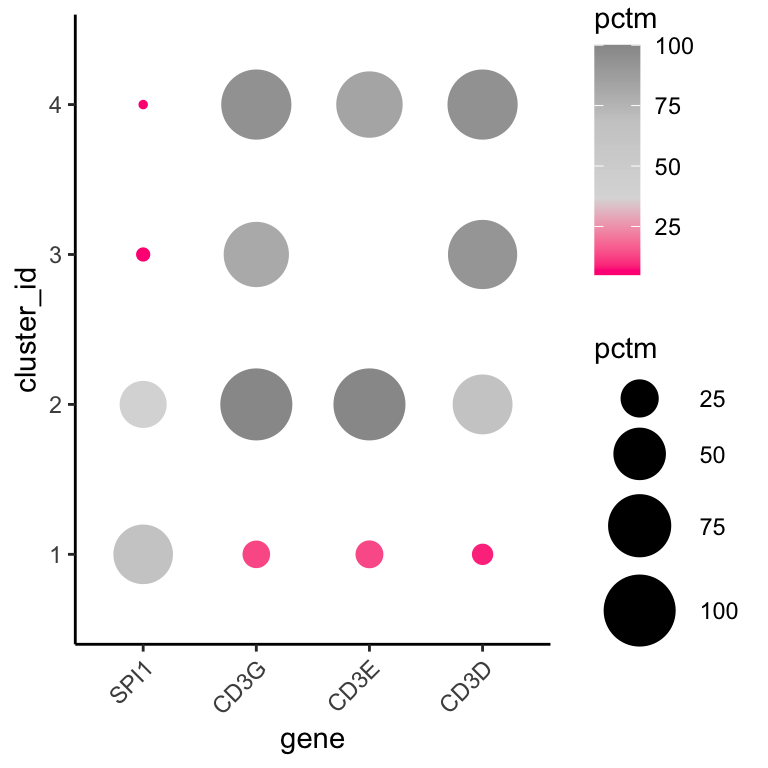

```r
dotM(obj, genes = cluster_promoter_markers$gene, groupBy = "cluster_id", matrix = "cg_promoter") +
  scale_color_gradientn(colors =  c("#FF0082", "#dbdbdb", "#cccccc", "#999999")) + scale_size(range = c(1, 12))
```

Another method one could use is by comparison to an annotated reference. While few exist, we have put aggregated methylation levels per group over high-confidence PBMC DMRs on Github. First download this data and calculate average methylation levels per cluster for each DMR (windows or any feature can also work)

```r
download.file("https://raw.githubusercontent.com/lrylaarsdam/amethyst/main/pbmc_vignette/pbmc_ref.RData", "~/Downloads/pbmc_ref.RData")
ref <- readRDS("~/Downloads/pbmc_ref.RData")

obj@genomeMatrices[["pbmc_dmrs_aggregated"]] <- aggregateMatrix(obj, matrix = "pbmc_dmrs", groupBy = "cluster_id")
```

Now view correlation profiles

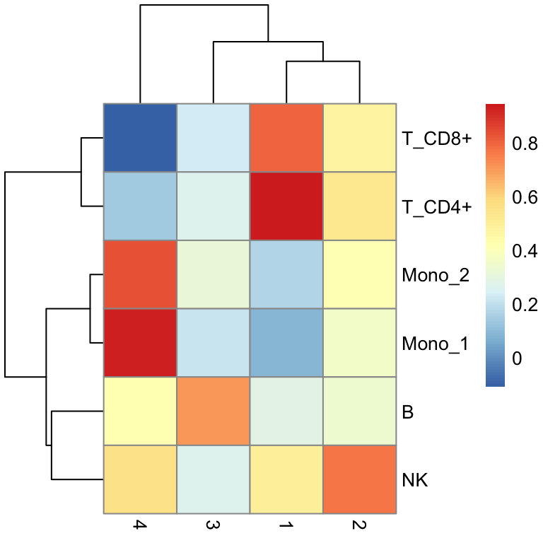

```r
cor <- cor(merge(ref,
                 obj@genomeMatrices[["pbmc_dmrs_aggregated"]],
                 by = 0) |> tibble::column_to_rownames(var = "Row.names"), use = "pairwise.complete.obs")
cor <- cor[c(1:ncol(ref)), c((ncol(ref) + 1)):ncol(cor)]
pheatmap(cor)
```

Based on all these annotation tools, we can rename our clusters according to broad class using dplyr logic:

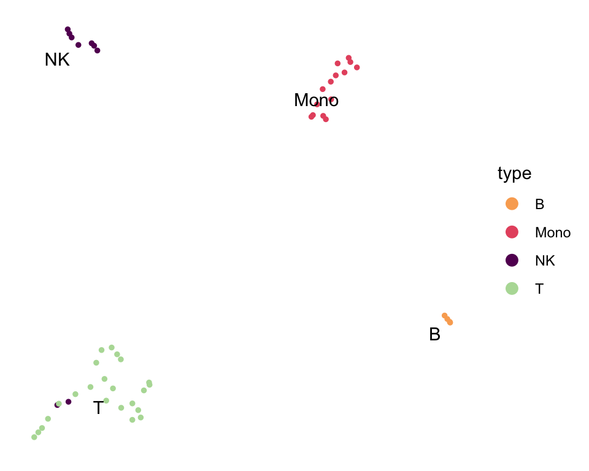

```r
obj@metadata[["type"]] <- dplyr::recode(obj@metadata[["cluster_id"]],
                                             "1" = "T",
                                             "2" = "NK",
                                             "3" = "B",
                                             "4" = "Mono")
library(ggrepel)
dimFeature(obj, colorBy = type, colors = pal, pointSize = 1)  +
  geom_text_repel(aes(label = type), color = "black", data = obj@metadata |> dplyr::group_by(type) |> dplyr::summarise(umap_x = median(umap_x), umap_y = median(umap_y)))
```

You might also want cluster tracks with the group name:

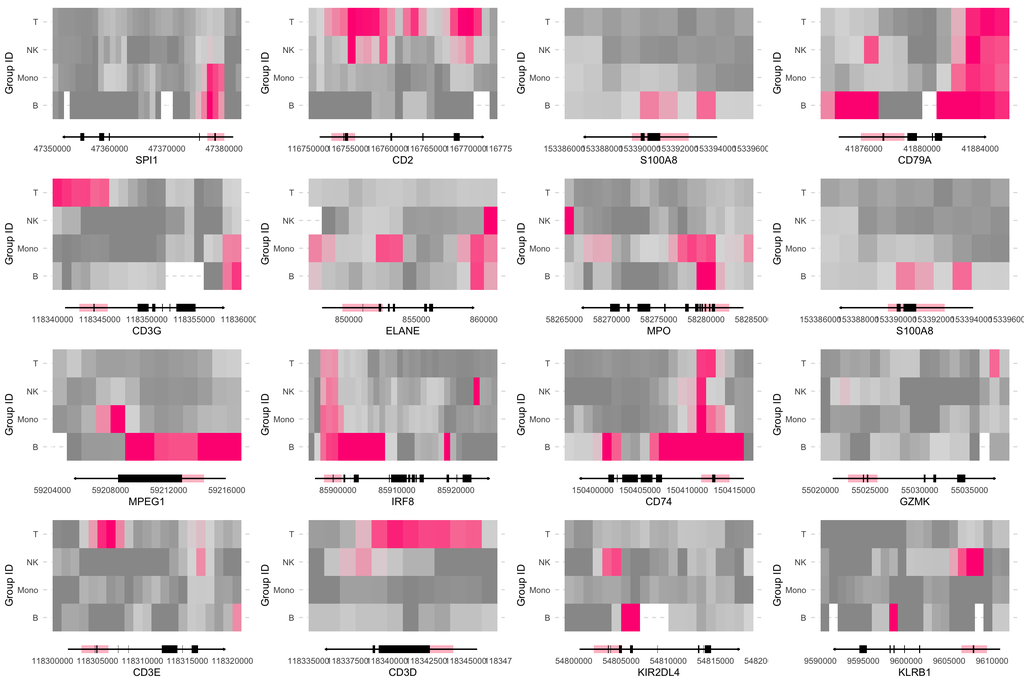

```r
obj@genomeMatrices[["cg_type_tracks"]] <- copy(obj@genomeMatrices[["cg_cluster_tracks"]])
setnames(obj@genomeMatrices[["cg_type_tracks"]], c("chr", "start", "end", "T", "NK", "B", "Mono"))
heatMap(obj,
        genes = c("SPI1", "CD2", "S100A8",  "CD79A", "CD3G", "ELANE", "MPO",
           "S100A8", "MPEG1", "IRF8", "CD74", "GZMK", "CD3E", "CD3D", "KIR2DL4", "KLRB1"),
        matrix = "cg_type_tracks",
        nrow = 4,
        legend = FALSE,
        width = 1000)
```

### DIFFERENTIALLY METHYLATED REGION ANALYSIS

There are two main formats to set up DMR analysis. The first is to test DMRs for each cluster against all others. Only the sum matrix (which we saved at the calcSmoothedWindows step) is needed, or regenerate with your annotated cell types:

```r
dmrs <- testDMR(cluster1kbwindows[["sum_matrix"]], eachVsAll = TRUE, nminTotal = 5, nminGroup = 5) # or use cluster1kbwindows[["sum_matrix"]] and rename
```

```
##
## Finished group 1
## Finished group 2
## Finished group 3
## Finished group 4
```

Then expand and filter the resulting list according to the desired stringency.

```r
dmrs <- filterDMR(dmrs, method = "bonferroni", filter = TRUE, pThreshold = 0.01, logThreshold = 2)
head(dmrs)
```

```
##     chr   start     end test         pval   logFC         padj direction
## 1: chr1  868000  869000    1 3.782380e-16  3.2990 2.278478e-09     hyper
## 2: chr1  906000  907000    1 1.489341e-15  3.3188 8.971681e-09     hyper
## 3: chr1 1347000 1348000    1 7.903053e-19  2.8856 4.760740e-12     hyper
## 4: chr1 1512000 1513000    1 2.128572e-11  4.2218 1.282236e-04     hyper
## 5: chr1 1513000 1514000    1 3.860030e-12  2.0069 2.325253e-05     hyper
## 6: chr1 2229000 2230000    1 7.697355e-23 -3.9756 4.636829e-16      hypo
```

Especially since the matrix is smoothed, adjacent genomic windows may be significant. You can collapse them with the following function. If annotation = T, any overlapping genes will be noted in the results table.

```r
collapsed_dmrs <- collapseDMR(obj, dmrs, maxDist = 4000, minLength = 2000, reduce = T, annotate = T)
head(collapsed_dmrs)
```

```
##     chr dmr_start dmr_end test direction dmr_length     dmr_padj dmr_logFC
## 1: chr1   1199000 1206000    3      hypo       7000 3.846260e-04      -Inf
## 2: chr1   1512000 1514000    1     hyper       2000 2.325253e-05    4.2218
## 3: chr1   1736000 1739000    3      hypo       3000 3.070292e-15   -3.1872
## 4: chr1   2229000 2232000    1      hypo       3000 4.162458e-23   -3.9756
## 5: chr1   3577000 3579000    3      hypo       2000 4.171638e-03      -Inf
## 6: chr1   3857000 3859000    3      hypo       2000 6.443386e-04      -Inf
##                                                     gene_names
## 1:                                                    TNFRSF18
## 2:                                                      ATAD3A
## 3: ENSG00000268575, ENSG00000227775, ENSG00000290854, SLC35E2A
## 4:                                                         SKI
## 5:                                                       MEGF6
## 6:                                                CEP104, DFFB
```

Note: The “test” column indicates which cluster is considered the member group. If you are testing a renamed matrix, you might want to add those names To your results instead of having the numerical order in which they were tested (which works ok for cluster DMRs). Change sumMatrix if necessary.

```r
key <- data.frame(test = as.factor(1:4),
                type = c("T", "NK", "B", "Mono"))
collapsed_dmrs <- left_join(collapsed_dmrs, key, by = "test")
head(collapsed_dmrs)
```

```
##     chr dmr_start dmr_end test direction dmr_length     dmr_padj dmr_logFC
## 1: chr1   1199000 1206000    3      hypo       7000 3.846260e-04      -Inf
## 2: chr1   1512000 1514000    1     hyper       2000 2.325253e-05    4.2218
## 3: chr1   1736000 1739000    3      hypo       3000 3.070292e-15   -3.1872
## 4: chr1   2229000 2232000    1      hypo       3000 4.162458e-23   -3.9756
## 5: chr1   3577000 3579000    3      hypo       2000 4.171638e-03      -Inf
## 6: chr1   3857000 3859000    3      hypo       2000 6.443386e-04      -Inf
##                                                     gene_names type
## 1:                                                    TNFRSF18    B
## 2:                                                      ATAD3A    T
## 3: ENSG00000268575, ENSG00000227775, ENSG00000290854, SLC35E2A    B
## 4:                                                         SKI    T
## 5:                                                       MEGF6    B
## 6:                                                CEP104, DFFB    B
```

If specific comparisons are desired, a data frame can be provided describing the tests. Three columns should be included: One listing members of group A, one listing members of group B, and one with the name of the test.

```r
comparisons <- data.frame(
  stringsAsFactors = FALSE,
              name = c("test1", "test2", "test3"),
                 A = c("1,2,3", "1", "2,3"),
                 B = c("1,4", "2", "1")
)
dmrs <- testDMR(sumMatrix = cluster1kbwindows[["sum_matrix"]], comparisons = comparisons, nminTotal = 5, nminGroup = 5)
```

### INVESTIGATING DMR RESULTS

First, let’s look at how many DMRs were identified in each group:

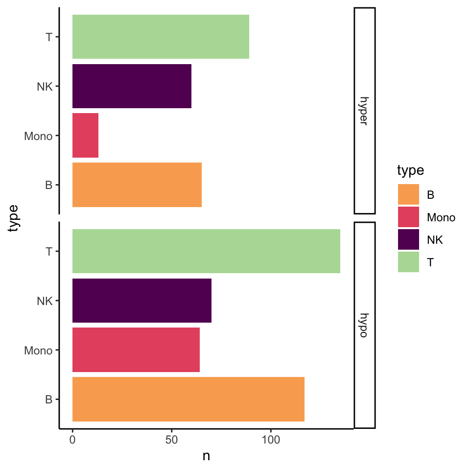

```r
ggplot(collapsed_dmrs |> dplyr::group_by(type, direction) |> dplyr::summarise(n = n()),
       aes(y = type, x = n, fill = type)) + geom_col() +
  facet_grid(vars(direction), scales = "free_y") + scale_fill_manual(values = pal) + theme_classic()
```

Isolate top results per group We find it helpful to select by a combined metric of logFC and padj, but you can modify as necessary:

```r
top_dmrs <- collapsed_dmrs |>
  dplyr::group_by(type, direction) |>
  dplyr::arrange(dmr_padj, .by_group = TRUE) |> dplyr::mutate(rank_padj = 1:n()) |>
  dplyr::arrange(desc(abs(dmr_logFC)), .by_group = TRUE) |> dplyr::mutate(rank_logFC = 1:n()) |>
  rowwise() |> dplyr::mutate(total_rank = sum(rank_padj, rank_logFC)) |>
  group_by(test, direction) |> slice_min(n = 1, order_by = total_rank) |>
  dplyr::mutate(location = paste0(chr, "_", (dmr_start - 2000), "_", (dmr_end + 2000))) |> dplyr::arrange(direction)
```

Plotting top hypomethylated regions for each group shows expected patterns based on known marker genes:

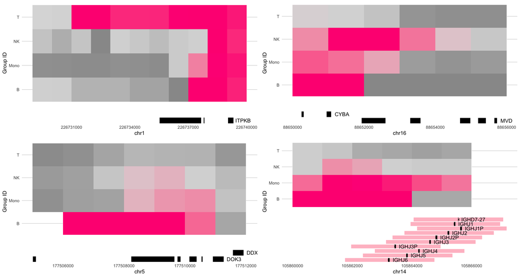

```r
heatMap(obj, matrix = "cg_type_tracks", regions = top_dmrs$location[top_dmrs$direction == "hypo"], nrow = 2, legend = FALSE, width = 1000, arrowOverhang = 0)
```

### GO ANALYSIS

Further interpretation of the results can be explored using a wide variety of packages available on R. In this example, we will use the topGO package to test for Gene Ontology (GO) term enrichments for genes with hypomethylated regions in the T cell group.

```r
library(topGO)
background <- rownames(obj@genomeMatrices[["cg_promoter"]]) # all genes tested
query <- unlist(strsplit(collapsed_dmrs$gene_names[collapsed_dmrs$type == "T" & collapsed_dmrs$direction == "hypo"], ", "))

GOdata <- new("topGOdata",
              description = "GO Enrichment Analysis",
              ontology = "BP",
              allGenes = setNames(factor(as.integer(background %in% query), levels = c(0, 1)), background),
              geneSel = function(x) x == 1,
              nodeSize = 10,
              annot = annFUN.org,
              mapping = "org.Hs.eg.db",
              ID = "symbol")
resultElim <- runTest(GOdata, algorithm = "elim", statistic = "fisher")
resultElim <- GenTable(GOdata, Fisher = resultElim, topNodes = 500, numChar = 60)
resultElim <- resultElim |> dplyr::filter(Fisher < 0.01 & Significant > 5) |> dplyr::mutate(fold_change = Significant/Expected, Fisher = as.numeric(Fisher))
resultElim <- janitor::clean_names(resultElim)
```

As expected, top results are strongly related to T cell processes:

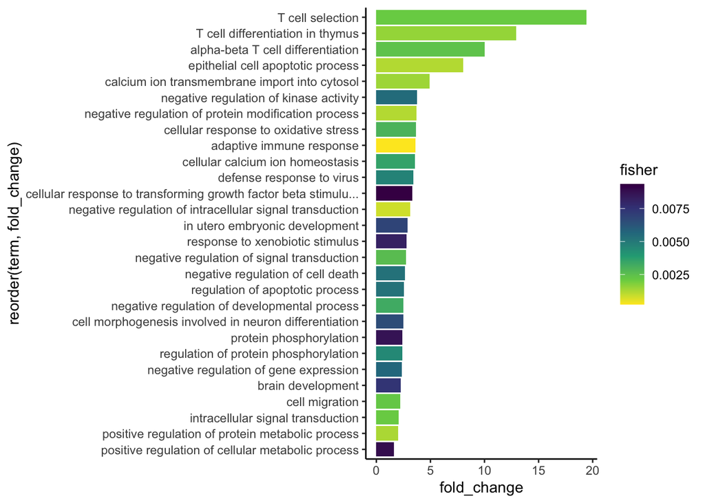

```r
ggplot(resultElim, aes(x = fold_change, y = reorder(term, fold_change), fill = fisher)) + geom_col() + theme_classic() + scale_fill_viridis_c(direction = -1)
```

### CONCLUSION

Thanks for trying out Amethyst! Additional utilities are still to come. We are also open to suggestions. Good luck in your analysis!